# PML_CourseProject

Sunil Kumar

June 13, 2018

```r
library(caret)
```

```r
library(rpart)
library(rpart.plot)
library(RColorBrewer)
library(rattle)
library(ggplot2)
library(randomForest)
library(knitr)
```

## Executive Summary

The goal of this course project work is to predict as “how (well)” weightlifting exercise was performed by the subjects wearing fitness wearables.

This is based on a study reference http://web.archive.org/web/20161224072740/http:/groupware.les.inf.puc-rio.br/har. The training & testing data are taken from https://d396qusza40orc.cloudfront.net/predmachlearn/pml-training.csv & pml-testing.csv. The dataset has “classe” as outcome and remaining predictor columns.

Six young health participants were asked to perform one set of 10 repetitions of the Unilateral Dumbbell Biceps Curl in five different fashions: -  
“CORRECT classe A” - exactly according to the specification  
“classe B” - throwing the elbows to the front  
“classe C” - lifting the dumbbell only halfway  
“classe D” - lowering the dumbbell only halfway  
“classe E” - throwing the hips to the front

The approach to identifying appropriate machine learning model and consequent prediction has been explained.

Q1. How you built your model?  
A1. I tried finding model with 3 alternatives: - Decision Tree, RandomForest, and GBM of which RandomForest has been found to be giving best accuracy (0.9939).

Q2. How you used cross validation?  
A2. I splitted clearned training data into 60% for training and 40% for validation as this dataset has quite big no of observations.

Q3. What you think the expected out of sample error is?  
A3. Expected out-of-sample error is 0.61%. Refer to last section.

Q4. Why you made the choices you did?  
A4. Choices/decisions reasoning has been exlained in each section.

### Loading data

- Read both “na” & “NA” as NA
- Read blank cells “” too as NA => As there are quite many blank cells, their imputation by mean or such alternative will not make sense for accelerometer & derived variables
- Read divide-by-zero-error “#DIV/0!” too as NA => as there are quite a few such instances

```r
training <- read.csv("./pml_training.csv", blank.lines.skip=TRUE, na.strings=c("", "na", "NA", "#DIV/0!"))
testing <- read.csv("./pml_testing.csv", blank.lines.skip=TRUE, na.strings=c("", "na", "NA", "#DIV/0!"))
```

- Training data set 19622 x 160
- Testing data set 20 x 160

```r
dim(training); dim(testing);
```

```
## [1] 19622   160
```

```
## [1]  20 160
```

## Data exploration & cleaning

```r
nzvTestMetrics <- nearZeroVar(testing, saveMetrics = T)
zvTest_T <- which(nzvTestMetrics$zeroVar == T)
redundantTestVars = names(testing)[zvTest_T]
```

- Remove zvTest_T variables & also those variables containing “<sup>X|</sup>user_name|timestamp|window”
- Confirmed that cleaned ‘training’ data after removing redundant variables (suggested by ‘testing’ data) do not have any further zeroVar or nearZeroVar

```r
trainCleaned = training[, -(zvTest_T)]

metadataVars <- grepl("^X|^user_name|timestamp|window", names(trainCleaned))
trainCleaned <- trainCleaned[, !(metadataVars)]
dim(trainCleaned)
```

```
## [1] 19622    53
```

- Perform exact same cleaning of redundant/zeroVar variables from ‘testing’ dataset too & also remove last column ‘problem_id’ which is a dummy replacement for ‘classe’

```r
testFinal = testing[, -(zvTest_T)]

metadataVars <- grepl("^X|^user_name|timestamp|window", names(testFinal))
testFinal <- testFinal[, !(metadataVars)]
testFinal = testFinal[, -(dim(testFinal)[2])]
dim(testFinal)
```

```
## [1] 20 52
```

- Split ‘trainCleaned’ dataset into ‘trainFinal’ & ‘validateFinal’ dataset
- As this dataset has huge no of observations (19622), hence using only 60% of them for training and rest for validation

```r
set.seed(12345)
idxTrain<- createDataPartition(trainCleaned$classe, p=0.6, list=FALSE)

trainFinal <- trainCleaned[idxTrain, -1]
dim(trainFinal)
```

```
## [1] 11776    52
```

```r
validateFinal <- trainCleaned[-idxTrain, -1]
dim(validateFinal)
```

```
## [1] 7846   52
```

## Decision Tree model fitting & prediction

```r
set.seed(12345)
modFitRpart <- rpart(classe ~ ., data=trainFinal, method="class")
```

- Decision tree plot of this large model involving 52 variables will not give any visual clarity, hence rely on confusion matrix data for assessing

```r
# fancyRpartPlot(modFitA1)
```

```r
predictRpart <- predict(modFitRpart, validateFinal, type = "class")
cmDecisionTree <- confusionMatrix(predictRpart, validateFinal$classe)
cmDecisionTree
```

```
## Confusion Matrix and Statistics
##
##           Reference
## Prediction    A    B    C    D    E
##          A 2002  255   59  107   62
##          B   68  785   67   71   51
##          C   35  105  948  255  139
##          D  108  268  258  756  158
##          E   19  105   36   97 1032
##
## Overall Statistics
##
##                Accuracy : 0.7039
##                  95% CI : (0.6937, 0.714)
##     No Information Rate : 0.2845
##     P-Value [Acc > NIR] : < 2.2e-16
##
##                   Kappa : 0.6246
##  Mcnemar's Test P-Value : < 2.2e-16
##
## Statistics by Class:
##
##                      Class: A Class: B Class: C Class: D Class: E
## Sensitivity            0.8970   0.5171   0.6930  0.58787   0.7157
## Specificity            0.9140   0.9594   0.9176  0.87927   0.9599
## Pos Pred Value         0.8056   0.7534   0.6397  0.48837   0.8006
## Neg Pred Value         0.9571   0.8923   0.9340  0.91585   0.9375
## Prevalence             0.2845   0.1935   0.1744  0.16391   0.1838
## Detection Rate         0.2552   0.1001   0.1208  0.09635   0.1315
## Detection Prevalence   0.3167   0.1328   0.1889  0.19730   0.1643
## Balanced Accuracy      0.9055   0.7383   0.8053  0.73357   0.8378
```

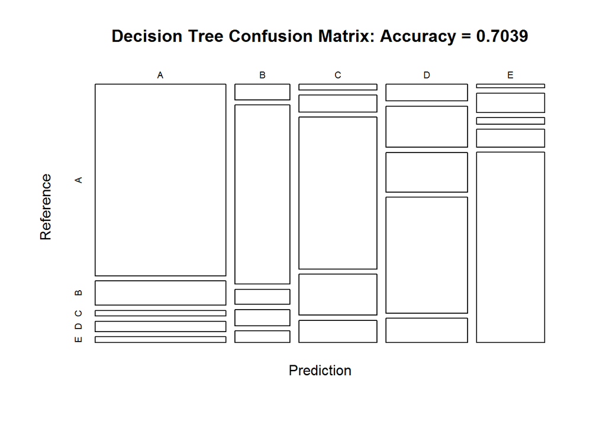

```r
plot(cmDecisionTree$table, col = cmDecisionTree$byClass, main = paste("Decision Tree Confusion Matrix: Accuracy =", round(cmDecisionTree$overall['Accuracy'], 4)))
```

## RandomForest model fitting and prediction

```r
set.seed(12345)
modFitRandomForest <- randomForest(classe ~ ., data=trainFinal)
predictRandomForest <- predict(modFitRandomForest, validateFinal, type = "class")
cmRandomForest <- confusionMatrix(predictRandomForest, validateFinal$classe)
cmRandomForest
```

```
## Confusion Matrix and Statistics
##
##           Reference
## Prediction    A    B    C    D    E
##          A 2229    9    0    0    0
##          B    3 1504    7    0    0
##          C    0    5 1361   17    2
##          D    0    0    0 1267    3
##          E    0    0    0    2 1437
##
## Overall Statistics
##
##                Accuracy : 0.9939
##                  95% CI : (0.9919, 0.9955)
##     No Information Rate : 0.2845
##     P-Value [Acc > NIR] : < 2.2e-16
##
##                   Kappa : 0.9923
##  Mcnemar's Test P-Value : NA
##
## Statistics by Class:
##
##                      Class: A Class: B Class: C Class: D Class: E
## Sensitivity            0.9987   0.9908   0.9949   0.9852   0.9965
## Specificity            0.9984   0.9984   0.9963   0.9995   0.9997
## Pos Pred Value         0.9960   0.9934   0.9827   0.9976   0.9986
## Neg Pred Value         0.9995   0.9978   0.9989   0.9971   0.9992
## Prevalence             0.2845   0.1935   0.1744   0.1639   0.1838
## Detection Rate         0.2841   0.1917   0.1735   0.1615   0.1832
## Detection Prevalence   0.2852   0.1930   0.1765   0.1619   0.1834
## Balanced Accuracy      0.9985   0.9946   0.9956   0.9924   0.9981
```

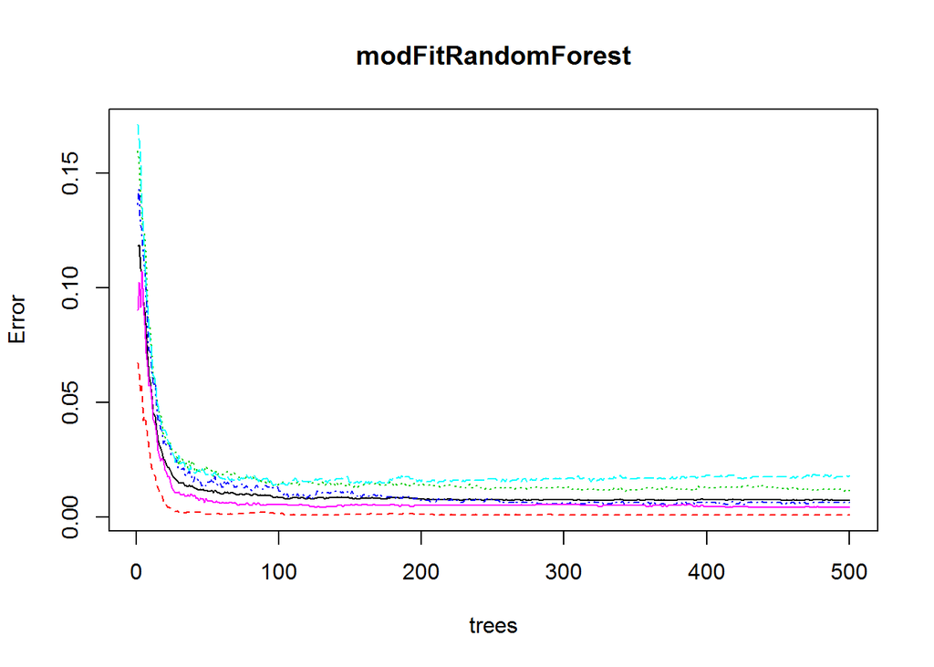

```r
plot(modFitRandomForest)
```

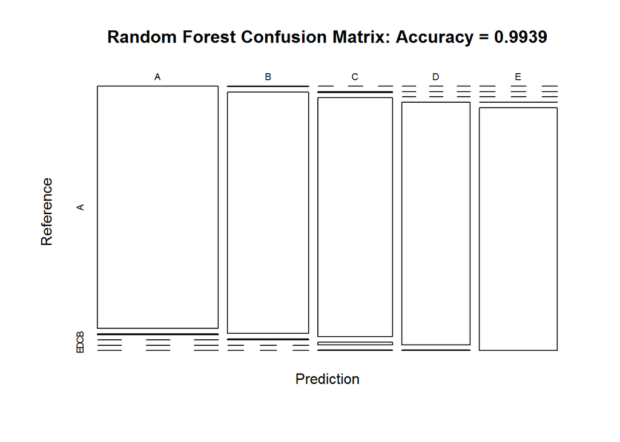

```r
plot(cmRandomForest$table, col = cmRandomForest$byClass, main = paste("Random Forest Confusion Matrix: Accuracy =", round(cmRandomForest$overall['Accuracy'], 4)))
```

## GBM model fitting and prediction

```r
set.seed(12345)
fitControl <- trainControl(method = "repeatedcv",
                           number = 5,
                           repeats = 1)

modFitGBM <- train(classe ~ ., data=trainFinal, method = "gbm",
                 trControl = fitControl,
                 verbose = FALSE)

finalModelGBM <- modFitGBM$finalModel

predictGBM <- predict(modFitGBM, newdata=validateFinal)
accuracyGBM <- confusionMatrix(predictGBM, validateFinal$classe)
accuracyGBM
```

```
## Confusion Matrix and Statistics
##
##           Reference
## Prediction    A    B    C    D    E
##          A 2206   47    0    3    0
##          B   21 1420   35    3   17
##          C    1   42 1315   52   13
##          D    4    5   17 1220   20
##          E    0    4    1    8 1392
##
## Overall Statistics
##
##                Accuracy : 0.9627
##                  95% CI : (0.9582, 0.9667)
##     No Information Rate : 0.2845
##     P-Value [Acc > NIR] : < 2.2e-16
##
##                   Kappa : 0.9527
##  Mcnemar's Test P-Value : NA
##
## Statistics by Class:
##
##                      Class: A Class: B Class: C Class: D Class: E
## Sensitivity            0.9884   0.9354   0.9613   0.9487   0.9653
## Specificity            0.9911   0.9880   0.9833   0.9930   0.9980
## Pos Pred Value         0.9778   0.9492   0.9241   0.9637   0.9907
## Neg Pred Value         0.9953   0.9846   0.9917   0.9900   0.9922
## Prevalence             0.2845   0.1935   0.1744   0.1639   0.1838
## Detection Rate         0.2812   0.1810   0.1676   0.1555   0.1774
## Detection Prevalence   0.2875   0.1907   0.1814   0.1614   0.1791
## Balanced Accuracy      0.9897   0.9617   0.9723   0.9708   0.9816
```

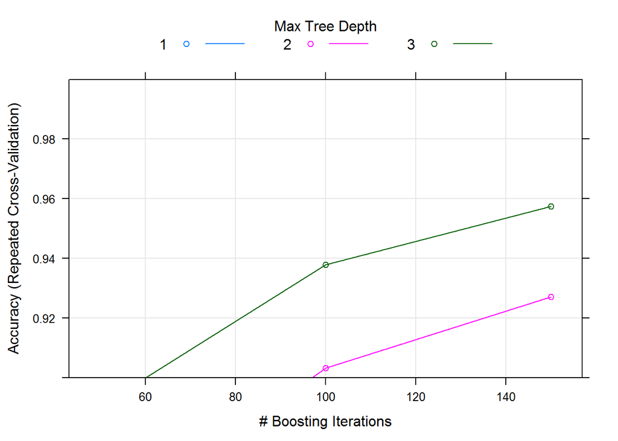

```r
plot(modFitGBM, ylim=c(0.9, 1))
```

## Predicting Results on the Test Data

- Accuracy of RandomForest is 0.9939 which is better than Rpart Decision Tree accuracy 0.7039 & GBM accuracy 0.9627
- The expected out-of-sample error is 100-99.39 = 0.61%

```r
predictFinal <- predict(modFitRandomForest, testFinal, type = "class")
predictFinal
```

```
##  1  2  3  4  5  6  7  8  9 10 11 12 13 14 15 16 17 18 19 20
##  B  A  B  A  A  E  D  B  A  A  B  C  B  A  E  E  A  B  B  B
## Levels: A B C D E
```